# UN Migration Data - Version 2

Winnie Hu

2/19/2020

## Load Data

```r
setwd("C:/Users/Winnie/Documents/NeilJohnson/Migration")
nodes <- read.csv("CountryNodes.csv", header=T, as.is=T)
links <- read.csv("EdgeList.csv", header=T, as.is=T)
```

## Examine Data

### i) Nodes and Links

```
##          Country          Region
## 1    Afghanistan   Southern Asia
## 2        Albania Southern Europe
## 3        Algeria Northern Africa
## 4 American Samoa       Polynesia
## 5        Andorra Southern Europe
## 6         Angola   Middle Africa
```

```
##   Destination         Origin Weight
## 1 Afghanistan        Albania      0
## 2 Afghanistan        Algeria      0
## 3 Afghanistan American Samoa      0
## 4 Afghanistan        Andorra      0
## 5 Afghanistan         Angola      0
## 6 Afghanistan       Anguilla      0
```

```
##                 Country         Region
## 170 Republic of Moldova Eastern Europe
## 171             Romania Eastern Europe
## 172  Russian Federation Eastern Europe
## 173              Rwanda Eastern Africa
## 174            RÃ©union Eastern Africa
## 175        Saint Helena Western Africa
```

The CountryNodes.csv file contains 232 countries and/or regions in the world. These countries are grouped into 22 regions, which are Southern Asia , Southern Europe , Northern Africa , Polynesia , Middle Africa , Caribbean , South America , Western Asia , Australia New Zealand, Western Europe , Eastern Europe , Central America , Western Africa , Northern America , Southern Africa , South Eastern Asia , Eastern Africa , Northern Europe , Eastern Asia , Melanesia , Micronesia , and Central Asia. There are 53,592 migration corridors in the EdgeList.csv file. The minimum weight is 0. The maximum weight is 11489684.

### ii) Percentile

```
##         75%         80%         85%         95%         96%         97%
##        0.00        6.00       88.00     4125.45     7405.92    13275.64
##         98%         99%        100%
##    26476.62    79680.20 11489684.00
```

The percentile values show that approximately 80% of the links are unweighted. Approximately 1 percent of the total links, equivalent to 536 links, have migration flow greater than 79,680.

### iii) Top migration corridors

|  | Destination | Origin | Weight |
| --- | --- | --- | --- |
| 50955 | United States of America | Mexico | 11489684 |
| 48944 | Turkey | Syrian Arab Republic | 3743494 |
| 50226 | United Arab Emirates | India | 3419875 |
| 50069 | Ukraine | Russian Federation | 3308515 |
| 39948 | Russian Federation | Ukraine | 3269248 |
| 22655 | India | Bangladesh | 3103664 |
| 50864 | United States of America | China | 2899267 |
| 50919 | United States of America | India | 2661470 |
| 39842 | Russian Federation | Kazakhstan | 2559711 |
| 25351 | Kazakhstan | Russian Federation | 2458414 |

[output cut: 90 more lines]

### iv) Top migration destinations (coutries)

|  | Destination | x |
| --- | --- | --- |
| 221 | United States of America | 48065741 |
| 82 | Germany | 13020724 |
| 183 | Saudi Arabia | 12680056 |
| 173 | Russian Federation | 11639894 |
| 219 | United Kingdom | 9491593 |
| 76 | France | 8334875 |
| 218 | United Arab Emirates | 8326184 |
| 39 | Canada | 7956487 |
| 12 | Australia | 7451863 |
| 106 | Italy | 6228525 |

[output cut: 222 more lines]

### v) Density

```r
# remove links with 0 weight
links_wonly <-links[!(links$Weight==0),]
head(links_wonly)
```

```
##     Destination     Origin Weight
## 157 Afghanistan   Pakistan 106528
## 203 Afghanistan Tajikistan   4596
## 223 Afghanistan Uzbekistan    229
## 268     Albania     Canada    856
## 315     Albania     Greece  29852
## 336     Albania      Italy   8405
```

```r
# Create an igraph object
net <- graph_from_data_frame(d=links_wonly, vertices=nodes, directed=T)

# directed network
no_edge <- ecount(net)
no_node <- vcount(net)
density_directed <- ecount(net)/(vcount(net)*(vcount(net)-1))
```

Density is the proportion of present edges from all possible edges in the network. Bsed on the density formular ecount(net)/(vcount(net)*(vcount(net)-1)) and knowing there are 232 nodes and 11305 edges, we derived that the network density for the migration dataset is 0.2109457.

### vi) Reciprocity

```r
# directed network
reciprocity_directed <- reciprocity(net)
```

Reciprocity is a measure of the likelihood of vertices to be mutually linked in a directed network. The reciprocity of the class network is 0.5109244.

## Visualization

### 1.1 Explore different layouts

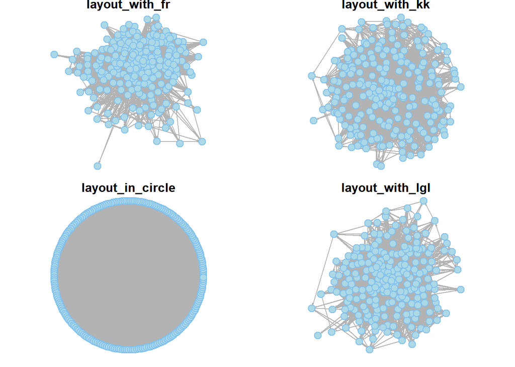

```r
# plot four figures - 2 rows, 2 columns
par(mfrow=c(2,2), mai=c(0.1, 0.1, 0.1, 0.1))

# make 4 subplots
# fr
plot(net, vertex.size=10, vertex.color="lightblue", edge.color="gray70", vertex.frame.color="SkyBlue2", edge.arrow.size=0.1, edge.width = (edge_attr(net)$weight)/1000000, vertex.label=NA, layout = layout_with_fr, main = "layout_with_fr")
# kk
plot(net, vertex.size=10, vertex.color="lightblue", edge.color="gray70", vertex.frame.color="SkyBlue2", edge.arrow.size=0.1, edge.width = (edge_attr(net)$weight)/1000000, vertex.label=NA, layout = layout_with_kk, main="layout_with_kk")
# circle
plot(net, vertex.size=10, vertex.color="lightblue", edge.color="gray70", vertex.frame.color="SkyBlue2", edge.arrow.size=0.1, edge.width = (edge_attr(net)$weight)/100000000, vertex.label=NA, layout = layout_in_circle, main="layout_in_circle")
#lgl
plot(net, vertex.size=10, vertex.color="lightblue", edge.color="gray70", vertex.frame.color="SkyBlue2", edge.arrow.size=0.1, edge.width = (edge_attr(net)$weight)/1000000, vertex.label=NA, layout = layout_with_lgl, main="layout_with_lgl")
```

### 1.2 Smart Questions

##### i) Degree analysis: What are the countries that are more open to migration?

```r
# rescale the range of node weights to range of (0, 1)
links_wonly$Weight_rescale <- rescale(x = links_wonly$Weight, to = c(0, 1), from = range(x = links_wonly$Weight, na.rm = TRUE, finite = TRUE))
head(links_wonly)
```

```
##     Destination     Origin Weight Weight_rescale
## 157 Afghanistan   Pakistan 106528   9.271535e-03
## 203 Afghanistan Tajikistan   4596   3.999240e-04
## 223 Afghanistan Uzbekistan    229   1.984389e-05
## 268     Albania     Canada    856   7.441459e-05
## 315     Albania     Greece  29852   2.598070e-03
## 336     Albania      Italy   8405   7.314388e-04
```

```r
#create igraph object
net_degree <- graph_from_data_frame(d=links_wonly, vertices=nodes, directed=T)

# get degree
deg <- degree(net_degree, mode='all')
deg_sort <- sort(x = deg, decreasing=TRUE)
col_deg <- data.frame(deg_sort) # covert vector to a dataframe
new_col_deg <- col_deg %>% rownames_to_column("Country") # convert rownames to a column refrence:https://rpubs.com/tuyenhavan/290871
colnames(new_col_deg) <- c("Country", "Degree") # reset column names
df_merge <- merge(nodes, new_col_deg) # merge two df based on common column "Country"
new_nodes <- df_merge[order(df_merge$Degree),] # sort the new df based on Degree in descending order
head(new_nodes, 10)
```

```
##                         Country           Region Degree
## 95                     Holy See  Southern Europe      2
## 134                     Mayotte   Eastern Africa      6
## 43              Channel Islands  Northern Europe      8
## 178   Saint Pierre and Miquelon Northern America      8
## 208                     Tokelau        Polynesia      8
## 228   Wallis and Futuna Islands        Polynesia     10
## 175                Saint Helena   Western Africa     11
## 72  Falkland Islands (Malvinas)    South America     12
## 104                 Isle of Man  Northern Europe     13
## 130            Marshall Islands       Micronesia     14
```

```r
tail(new_nodes, 10)
```

```
##                      Country                Region Degree
## 103                  Ireland       Northern Europe    266
## 201                   Sweden       Northern Europe    269
## 44                     Chile         South America    275
## 147              Netherlands        Western Europe    278
## 106                    Italy       Southern Europe    302
## 221 United States of America      Northern America    312
## 12                 Australia Australia New Zealand    318
## 39                    Canada      Northern America    329
## 76                    France        Western Europe    344
## 219           United Kingdom       Northern Europe    351
```

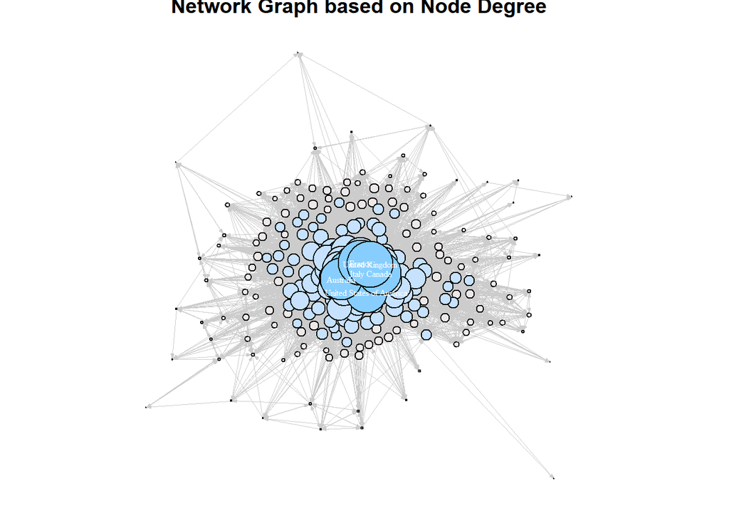

```r
###########
## Plot  ##
###########
# create new igraph object
net_degree2 <- graph_from_data_frame(d=links_wonly, vertices=new_nodes, directed=T)

# vertex color based on degree level
vcol <- rep("snow2", vcount(net_degree2))     #deebf7 # assigned third degree very light blue to top 101 - 232 countries
vcol[223:232] <- "skyblue1"                   #3182bd  #assign first degree dark blue to top ten countries
vcol[123:222] <- "slategray1"                 #9ecae1 #assign second degree light blue to top 11-100 countries
V(net_degree2)$color <- vcol

# vertex frame color
V(net_degree2)$frame.color <- "black"

# vertex label and size
V(net_degree2)$label <- new_nodes$Country
V(net_degree2)$label.cex <- 0.5
V(net_degree2)$label.color <- "white"

# Vertex size
V(net_degree2)$size <- round((new_nodes$Degree)/16, 2)

# edge color and size
E(net_degree2)$width <- links_wonly$Weight_rescale
E(net_degree2)$color <- "gray80"
E(net_degree2)$arrow.size <- .2
#E(net_degree)$arrow.mode <- 1

# layout
l <- layout_with_fr(net_degree2)

# plot
par(mai=c(0,0,0.1,0.1))
plot(net_degree2, layout = l, vertex.label = ifelse(degree(net_degree2) > 300, V(net_degree2)$label, NA), main="Network Graph based on Node Degree")
```

```r
#legend("topleft", legend=c("a", "b", "c"), col=c("snow2", "skyblue1", "slategray1"), lty=1:2, cex=0.8)
```

```r
nodes_vis <- new_nodes
colnames(nodes_vis) <- c("id", "group", "Degree")
head(nodes_vis)
```

```
##                            id            group Degree
## 95                   Holy See  Southern Europe      2
## 134                   Mayotte   Eastern Africa      6
## 43            Channel Islands  Northern Europe      8
## 178 Saint Pierre and Miquelon Northern America      8
## 208                   Tokelau        Polynesia      8
## 228 Wallis and Futuna Islands        Polynesia     10
```

```r
edges_vis <- links_wonly[, c("Destination", "Origin", "Weight_rescale")]
colnames(edges_vis) <- c("to", "from", "weight")
head(edges_vis)
```

```
##              to       from       weight
## 157 Afghanistan   Pakistan 9.271535e-03
## 203 Afghanistan Tajikistan 3.999240e-04
## 223 Afghanistan Uzbekistan 1.984389e-05
## 268     Albania     Canada 7.441459e-05
## 315     Albania     Greece 2.598070e-03
## 336     Albania      Italy 7.314388e-04
```

```r
visNetwork(nodes_vis, edges_vis) %>%
  visIgraphLayout(layout = "layout_with_fr")  %>%
  visLegend()
```

[interactive chart not shown]